# 16. Images II

As I have tried to emphasize all semester, the trick to building good supervised and unsupervised models is to start with good features. That is, we need to have each observation described by numeric features appropriate to the task at hand. With structured data, like the ones we focused on in DSST289, this is usually something that needs to be done at the time of the data collection. In some cases, particularly if data are stored in multiple tables, creating good features may also involve very custom approaches that require deep domain knowledge.

As I have said many times, the reason I focus on text in this course is that textual data provides many different rich options for creating features. This process is not trivial but at the same time there are several approaches that work across many different tasks. Our basic approach has been to use word counts, but we can adjust these by different kinds of filtering, using N-grams, using POS tags, and cycling between tokens and lemmas.

Images are even more difficult. Our initial data will consist of pixel intensities. For small relatively simple tasks and small images, we can unravel the image and treat each pixel intensity as its own feature. We saw that this did okay in the last set of notes on 64x64 square images of flowers. We also saw that constructing new features by transforming to HSV space and aggregating discrete buckets of the hues (for colorful pixels) and greys (for non-colorful pixels) produced an even better model. Hand constructing features, however, because essentially impossible in more complex cases. As we will see, even in this small example, the hand-created features can be easily improved on.

The secret to building better models is to use a class of techniques that fall under the umbrella of *Deep Learning*, specially a *neural network*. We can think of these models as combining the ideas from supervised learning and unsupervised learning. Conceptually, they a sequence of dimensionality reduction algorithms that transform the input image into lower-dimensional spaces, and then take the last set and build a supervised model that makes a prediction from labels in the training data. All of the elements are *learned* together at the same time to optimize the predicted values at the output of the model. We can think of the model as looking like this:

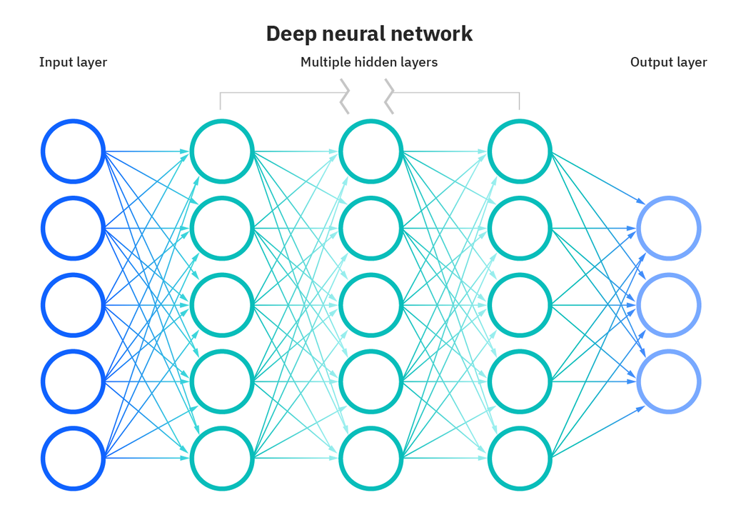

Each of the arrows corresponds to an element in a logistic regression (yes, these are really just arrays of logistic regressions). What the diagram calls *hidden layers* are just features that are automatically learned by the data. Let’s see how this works with our flowers data. We’ll start again by loading it into R:

```r
flowers <- read_csv("../data/flowers_17.csv.bz2")
x64 <- read_rds("../data/flowers_17_x64.rds")
x64 <- x64[flowers$class %in% 0:9,,,]
flowers <- flowers[flowers$class %in% 0:9,]
```

In the following, we’ll see three increasingly complex types of neural networks that we can use to predict the type of flower in the image.

## 1. Dense Neural Network

To build neural networks, I will use the **keras** library. It is a little less popular at the moment (PyTorch is currently the most frequently used in academic research). But, I think it is the best for the quick treatment we are doing here. Installing the R package is easy, but requires that you also have a working Python installation with a number of other packages installed; this is the part I did not want to try to do this semester.

```r
library(keras)
```

Here, we will start as we did last time by unraveling the image data into a large matrix.

```r
X <- t(apply(x64, 1, cbind))
y <- flowers$class

X_train <- X[flowers$train_id == "train",]
y_train <- to_categorical(y[flowers$train_id == "train"], num_classes = 10)
```

Now, we need to build an empty neural network. This requires describing exactly how many hidden layers exist, the number of features in each layer, and some additional details that are not important for the first pass of the material. Here, we will have three hidden layers with 128 inputs each.

```r
model <- keras_model_sequential()
model %>%
  layer_dense(units = 128, input_shape = c(64 * 64 * 3)) %>%
  layer_activation(activation = "relu") %>%
  layer_dense(units = 128) %>%
  layer_activation(activation = "relu") %>%
  layer_dense(units = 128) %>%
  layer_activation(activation = "relu") %>%
  layer_dense(units = 10) %>%
  layer_activation(activation = "softmax")

model %>% compile(loss = 'categorical_crossentropy',
                  optimizer = optimizer_rmsprop(),
                  metrics = c('accuracy'))

model
```

```
## Model: "sequential"
## ____________________________________________________________________________
##  Layer (type)                     Output Shape                  Param #
## ============================================================================
##  dense_3 (Dense)                  (None, 128)                   1572992
##  activation_3 (Activation)        (None, 128)                   0
##  dense_2 (Dense)                  (None, 128)                   16512
##  activation_2 (Activation)        (None, 128)                   0
##  dense_1 (Dense)                  (None, 128)                   16512
##  activation_1 (Activation)        (None, 128)                   0
##  dense (Dense)                    (None, 10)                    1290
##  activation (Activation)          (None, 10)                    0
## ============================================================================
## Total params: 1,607,306
## Trainable params: 1,607,306
## Non-trainable params: 0
## ____________________________________________________________________________
```

Once the model has been build, we need to train it with our data. This process is quite similar to the way that that we trained the **xgboost** models. We pass data for a given number of iterations until we are happy with the model. Here, I will run the algorithm for 60 different iterations through the training data.

```r
history <- model %>%
  fit(X_train, y_train, epochs = 60)
```

Once the model has been fit, we can make predictions just as we did with any other model.

```r
y_pred <- predict(model, X)
y_pred <- apply(y_pred, 1, which.max) - 1L
tapply(y == y_pred, flowers$train_id, mean)
```

```
##     train     valid
## 0.9966667 0.5750000
```

Notice that while the data are over fit in a sense, the neural network has done this in a way that still greatly outperforms the results from last time using our hand-constructed features.

## 2. Convolutional Neural Networks (CNN)

Above, we are still treating each of the pixel intensities as unrelated raw features. This is not very efficient because we know that the pixels have a spatial relationship with one another. In order to make use of this information in a deep learning model, we need to use something called a convolutional neural network, or CNN. Let’s start by recreating the data without collapsing it into a matrix.

```r
X <- x64
y <- flowers$class

X_train <- X[flowers$train_id == "train",,,,drop = FALSE]
y_train <- to_categorical(y[flowers$train_id == "train"], num_classes = 10)
```

I will now build a new model that replaces the first dense layer with a CNN layer. This has a similar structure to the first model, but the first two dense layers have been replaced with convolutional layers. These are restricted to only allow features that iteract nearby pixels with one another. They also must do the same kind of process to each part of the image. In theory, these layers would be more likely to create something similar to the HSV space that we created the first time.

```r
model <- keras_model_sequential()
model %>%
  layer_conv_2d(filters = 16, kernel_size = c(3, 3),
                  input_shape = dim(X_train)[-1],
                  padding = "same") %>%
  layer_max_pooling_2d(pool_size = c(2, 2)) %>%
  layer_conv_2d(filters = 16, kernel_size = c(3, 3),
                  input_shape = dim(X_train)[-1],
                  padding = "same") %>%
  layer_max_pooling_2d(pool_size = c(2, 2)) %>%
  layer_activation(activation = "relu") %>%
  layer_flatten() %>%
  layer_activation(activation = "relu") %>%
  layer_dense(units = 128) %>%

  layer_dense(units = 10) %>%
  layer_activation(activation = "softmax")

model %>% compile(loss = 'categorical_crossentropy',
                  optimizer = optimizer_rmsprop(),
                  metrics = c('accuracy'))
```

Training works the same as before:

```r
history <- model %>%
  fit(X_train, y_train, epochs = 25)
```

And we can again see how well the data predicts the validation labels:

```r
y_pred <- predict(model, X)
y_pred <- apply(y_pred, 1, which.max) - 1L
tapply(y == y_pred, flowers$train_id, mean)
```

```
## train valid
## 1.000 0.625
```

We can see that the CNN does a better job of predicting the labels of the flowers. While the improvement is noticeable even here, the difference between these two approaches would be vastly different larger images and more complex tasks. Working with HD images, for example, would be virtually impossible with the first approach. CNNs, however, can easily process and train models based on high-definition training images.

## 3. Transfer Learning

We will finish by looking at one of the most important features of deep learning algorithms. The internal layers of a neural network, as mentioned above, can be thought of as progressively predictive features that get used in the last layer to build a supervised model. What’s really interesting about this is that if we build a deep learning model with data and labels that are sufficiently varied and complex, the internal layers of the model end up being features that can be reused in different tasks. This is particularly powerful when we have a complex predictive modelling tasks but only a limited amount of training data.

The **keras** library contains several large, pre-trained neural network models. One of the best is called ResNet-50; the name comes from the fact that it has 50 hidden layers! We can load this model in R with the following:

```r
resnet50 <- application_resnet50(weights = 'imagenet', include_top = TRUE)
```

If we want to apply this model to new data, but get the hidden layer values rather than the final predictions for the task it was built on (object detection from 1000 categories), we can create a sub-model as follows:

```r
model_avg_pool <- keras_model(inputs = resnet50$input,
                              outputs = get_layer(resnet50, 'avg_pool')$output)
```

Once we have the model, we can apply the model to our flowers data set with the following:

```r
# This is not quite right, because our images are the wrong size for
# the network, but this gives you the general idea
X_pp <- imagenet_preprocess_input(X)
pred <- predict(model_avg_pool, x = X_pp)
```

I have cached the results from the code above; we will read the results in directly below. Notice that the output has 2048 (2^11) features.

```r
X <- read_rds("../data/flowers_17_resnet.rds")
dim(X)
```

```
## [1]  800 2048
```

Now that we have the internal features from the last hidden layer, we can create a training version of our data as before:

```r
X_train <- X[flowers$train_id == "train",]
y_train <- to_categorical(y[flowers$train_id == "train"], num_classes = 10)
```

And then fit a dense neural network that takes these as an input (you could fit an elastic net as well, which would prefer fairly well):

```r
model <- keras_model_sequential()
model %>%
  layer_dense(units = 128, input_shape = ncol(X)) %>%
  layer_activation(activation = "relu") %>%
  layer_dense(units = 128) %>%
  layer_activation(activation = "relu") %>%
  layer_dense(units = 128) %>%
  layer_activation(activation = "relu") %>%
  layer_dense(units = 10) %>%
  layer_activation(activation = "softmax")

model %>% compile(loss = 'categorical_crossentropy',
                  optimizer = optimizer_rmsprop(),
                  metrics = c('accuracy'))

model
```

```
## Model: "sequential_2"
## ____________________________________________________________________________
##  Layer (type)                     Output Shape                  Param #
## ============================================================================
##  dense_9 (Dense)                  (None, 128)                   262272
##  activation_10 (Activation)       (None, 128)                   0
##  dense_8 (Dense)                  (None, 128)                   16512
##  activation_9 (Activation)        (None, 128)                   0
##  dense_7 (Dense)                  (None, 128)                   16512
##  activation_8 (Activation)        (None, 128)                   0
##  dense_6 (Dense)                  (None, 10)                    1290
##  activation_7 (Activation)        (None, 10)                    0
## ============================================================================
## Total params: 296,586
## Trainable params: 296,586
## Non-trainable params: 0
## ____________________________________________________________________________
```

Which we can train as before:

```r
history <- model %>%
  fit(X_train, y_train, epochs = 10)
```

And once again see how predictive the model is:

```r
y_pred <- predict(model, X)
y_pred <- apply(y_pred, 1, which.max) - 1L
tapply(y == y_pred, flowers$train_id, mean)
```

```
## train valid
##  1.00  0.86
```

This is much better than the previous model, because it can use all of the information in the very large training data used to build ResNet-50. Again, the improvement here would be even more noticeable with a more complex dataset.

## 4. Transfer Learning: Visualization

The features created by the hidden layers of ResNet-50 can also be used to visualize the dataset of flowers. The output features have 2^11 values, far too many to plot. However, we could use our UMAP algorithm to collapse these into two dimensions as follows:

```r
rot <- umap::umap(X, n_components = 2L)$layout
df <- tibble(flower = flowers$class_name, v1 = rot[,1], v2 = rot[,2])
df
```

```
## # A tibble: 800 × 3
##    flower          v1    v2
##    <chr>        <dbl> <dbl>
##  1 crocus      -2.07   2.42
##  2 tigerlily    1.86  -2.29
##  3 sunflower   -2.00  -5.64
##  4 bluebell    -0.918  3.31
##  5 snowdrop     2.45   2.68
##  6 bluebell    -0.355  1.51
##  7 lily valley  3.69   2.24
##  8 tigerlily    2.41  -1.46
##  9 fritillary   0.483  4.12
## 10 tigerlily    2.06  -1.52
## # … with 790 more rows
```

Let’s compute the center of each flowers UMAP scores to put on the plot:

```r
centers <- df %>%
  group_by(flower) %>%
  summarize(v1 = median(v1), v2 = median(v2))
```

And finally, we can visualize the data:

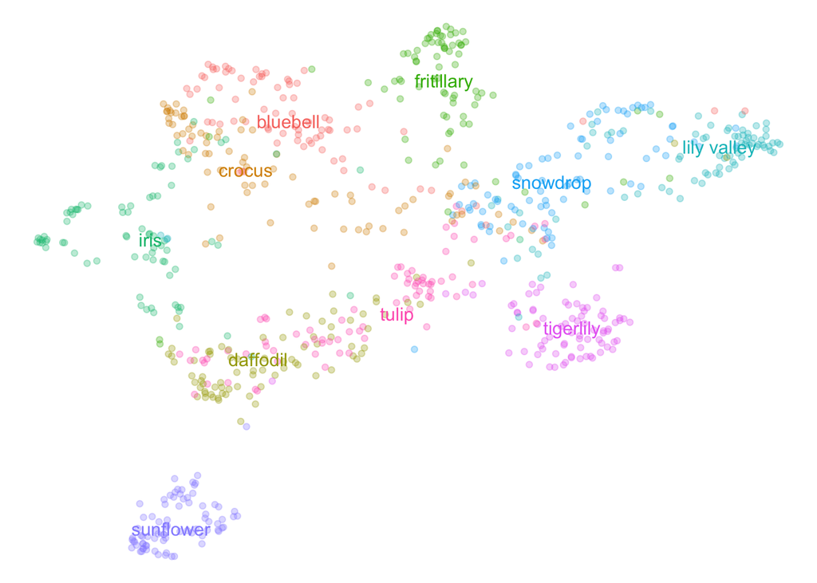

```r
df %>%
  ggplot(aes(v1, v2)) +
    geom_point(
      aes(color = flower),
      alpha = 0.3,
      show.legend = FALSE
    ) +
    geom_text(
      aes(label = flower, color = flower),
      data = centers,
      size = 4,
      show.legend = FALSE
    ) +
    theme_void()
```

Or, if you prefer, we can look at the actual images:

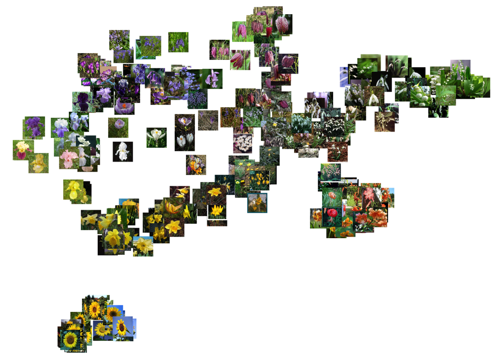

```r
library(ggimg)

df$img_array <- vector("list", nrow(df))
for (j in seq_len(nrow(df))) { df$img_array[j] <- list(x64[j,,,]) }

set.seed(1)
df %>%
  slice_sample(n = 250) %>%
  ggplot(aes(v1, v2)) +
    geom_point_img(aes(img = img_array), size = 0.8) +
    theme_void()
```

Not a bad place to stop with new material for the semester…

## 5. More?

If you want to do a much deeper dive into deep learning and neural networks, I recommend the free [Practical Deep Learning](https://course.fast.ai/) course offered by fast.ai. There is a lot of material there, including, code, data, notes, and a sequence of videos.